# Analyse des données d’enregistrement de naissance du serveur iCivil // Analysis of iCivil Birth Registration Data (Burkina Faso)

Ramoudane Orou Sannou

16/04/2020

# 1. Introduction

iCivil est une technologie d’enregistrement des faits d’état civil implémentée au Burkina Faso. Il s’agit d’une suite d’outils composée de smartphones distribués dans les formations sanitaires, d’ordinateurs et imprimantes présents dans les centres d’état civil des mairies et d’un serveur central installé à la Direction Générale de la Modernisation de l’Etat Civil (DGMEC) qui reçoit les données de l’ensemble du pays. Les smartphones sont utilisées par les agents de santé pour **enregistrer** systématiquement les naissances qui s’opèrent dans leurs locaux tandisque le dispositif installé dans les centres d’état civil permet après complément d’information, d’imprimer les actes de **déclaration** des faits d’état civil en question. Quant au serveur de la DGMEC, il stocke des données qui peuvent être utilisées pour produire des statistiques vitales. L’analyse qui va suivre utilise la première exportation de données du serveur.

iCivil is a newly introduced civil registration technology in Burkina Faso. It is a suite of tools consisting of smartphones distributed in health facilities, computers and printers in civil registration centers and a central server at the Directorate-General for the Modernisation of Civil Registration (DGMEC) which receives data from all over the country. Smartphones are used by health workers in maternity wards to systematically **register** births that take place on their premises, while computer installed in the civil registration centres makes it possible to print out the birth certificate (**declaration**). As for the server at DGMEC, it stores data that can be used to produce vital statistics. The following analysis uses the first data export from the server.

# 2. Téléversement des packages nécessaires // Uploading the necessary packages

# 3. Téléversement de la base de données // Uploading the database

La base de données contient un total de 12 variables portant sur la naissance, le lieu de naissance, la déclaration et les informations sur la mère du nouveau né.

The database has a total of 12 variables containing information on the newborn, place of birth, birth registration and mother.

| N° | Date_activation | Sexe | Date_heure | Lieu de naissance | GPS Lat. | GPS Long. | Personnel Déclarant | N°IMEI du Smartphone de Déclaration | Profession de la mère | Déclaré par | Date de naissance de la mère |
| --- | --- | --- | --- | --- | --- | --- | --- | --- | --- | --- | --- |
| 01 | 2020-03-18 07:29:00 | Masculin | 2020-03-17 12:43:00 | NOUNA | 12.75617 | -3.877577 | CSPS_DIOCESIEN | 3.53e+14 | NA | NA |  |
| 02 | 2020-03-18 07:22:00 | Féminin | 2020-03-17 07:40:00 | NOUNA | 12.75616 | -3.877474 | CSPS_DIOCESIEN | 3.53e+14 | NA | NA |  |
| 03 | 2020-03-18 02:10:00 | Féminin | 2020-03-17 18:15:00 | KAYA | 13.06218 | -1.087752 | CLINIQUE_EPHRAIM | 3.53e+14 | NA | NA |  |
| 04 | 2020-03-18 02:04:00 | Masculin | 2020-03-18 00:09:00 | KAYA | 13.06204 | -1.087689 | CLINIQUE_EPHRAIM | 3.53e+14 | NA | NA |  |
| 05 | 2020-03-17 21:18:00 | Féminin | 2020-03-17 18:50:00 | KAYA | NA | NA | CHR_KAYA | 3.53e+14 | NA | NA |  |
| 06 | 2020-03-17 20:27:00 | Masculin | 2020-03-17 18:30:00 | KAYA | NA | NA | CHR_KAYA | 3.53e+14 | NA | NA |  |
| 07 | 2020-03-17 19:16:00 | Féminin | 2020-03-17 17:30:00 | KAYA | NA | NA | CHR_KAYA | 3.53e+14 | NA | NA |  |
| 08 | 2020-03-17 18:42:00 | Masculin | 2020-03-17 14:30:00 | KAYA | 13.18412 | -1.235491 | CSPS_ZORKOUM | 3.53e+14 | NA | NA |  |
| 09 | 2020-03-17 18:40:00 | Masculin | 2020-03-17 13:30:00 | KAYA | 13.18412 | -1.235491 | CSPS_ZORKOUM | 3.53e+14 | NA | NA |  |
| 10 | 2020-03-17 18:38:00 | Féminin | 2020-03-17 13:00:00 | KAYA | 13.18394 | -1.235398 | CSPS_ZORKOUM | 3.53e+14 | NA | NA |  |

[output cut: 6721 more lines]

# 4. Transformation de la base de données // Tidying the database

Sur le logiciel R le concept de ‘’Tidy data’’ est souvent utilisé et fait allusion à la présentation de toute base de données dans un format bien spécifique répondant à trois règles de base:

- Les colonnes contiennent une et une seule variable
- Les lignes représentent les observations
- Une unité d’observation par tableau

Nous allons essayer donc de transformer la base de données de façon à ce qu’elle réponde à ces critères.

On R, the concept of ‘’Tidy data’’ is often used and refers to presenting any database in a very specific format that meets three basic rules:

- Columns contain one and only one variable
- Rows represent observations
- One type of observational unit per table

We’re going to transform this database so that it meets these criteria.

| N° | date_activation | heure_activation | Sexe | date_naissance | heure_naissance | Lieu de naissance | GPS Lat. | GPS Long. | Personnel Déclarant | N°IMEI du Smartphone de Déclaration | Profession de la mère | Déclaré par | date_naissance_mere | heure_naissance_mere |
| --- | --- | --- | --- | --- | --- | --- | --- | --- | --- | --- | --- | --- | --- | --- |
| 01 | 2020-03-18 | 07:29:00 | Masculin | 2020-03-17 | 12:43:00 | NOUNA | 12.75617 | -3.877577 | CSPS_DIOCESIEN | 3.53e+14 | NA | NA | NA | NA |
| 02 | 2020-03-18 | 07:22:00 | Féminin | 2020-03-17 | 07:40:00 | NOUNA | 12.75616 | -3.877474 | CSPS_DIOCESIEN | 3.53e+14 | NA | NA | NA | NA |
| 03 | 2020-03-18 | 02:10:00 | Féminin | 2020-03-17 | 18:15:00 | KAYA | 13.06218 | -1.087752 | CLINIQUE_EPHRAIM | 3.53e+14 | NA | NA | NA | NA |
| 04 | 2020-03-18 | 02:04:00 | Masculin | 2020-03-18 | 00:09:00 | KAYA | 13.06204 | -1.087689 | CLINIQUE_EPHRAIM | 3.53e+14 | NA | NA | NA | NA |
| 05 | 2020-03-17 | 21:18:00 | Féminin | 2020-03-17 | 18:50:00 | KAYA | NA | NA | CHR_KAYA | 3.53e+14 | NA | NA | NA | NA |
| 06 | 2020-03-17 | 20:27:00 | Masculin | 2020-03-17 | 18:30:00 | KAYA | NA | NA | CHR_KAYA | 3.53e+14 | NA | NA | NA | NA |

| date_activation | Sexe | date_naissance_enfant | lieu_naissance | lat | long | declarant | date_naissance_mere |
| --- | --- | --- | --- | --- | --- | --- | --- |
| 2020-03-18 | Masculin | 2020-03-17 | NOUNA | 12.75617 | -3.877577 | NA | NA |
| 2020-03-18 | Féminin | 2020-03-17 | NOUNA | 12.75616 | -3.877474 | NA | NA |
| 2020-03-18 | Féminin | 2020-03-17 | KAYA | 13.06218 | -1.087752 | NA | NA |
| 2020-03-18 | Masculin | 2020-03-18 | KAYA | 13.06204 | -1.087689 | NA | NA |
| 2020-03-17 | Féminin | 2020-03-17 | KAYA | NA | NA | NA | NA |
| 2020-03-17 | Masculin | 2020-03-17 | KAYA | NA | NA | NA | NA |

```
## tibble [6,731 × 8] (S3: tbl_df/tbl/data.frame)
##  $ date_activation      : chr [1:6731] "2020-03-18" "2020-03-18" "2020-03-18" "2020-03-18" ...
##  $ Sexe                 : chr [1:6731] "Masculin" "Féminin" "Féminin" "Masculin" ...
##  $ date_naissance_enfant: chr [1:6731] "2020-03-17" "2020-03-17" "2020-03-17" "2020-03-18" ...
##  $ lieu_naissance       : chr [1:6731] "NOUNA" "NOUNA" "KAYA" "KAYA" ...
##  $ lat                  : chr [1:6731] "12.75617" "12.75616" "13.06218" "13.06204" ...
##  $ long                 : chr [1:6731] "-3.877577" "-3.877474" "-1.087752" "-1.087689" ...
##  $ declarant            : chr [1:6731] NA NA NA NA ...
##  $ date_naissance_mere  : chr [1:6731] NA NA NA NA ...
```

# 5. Statistiques descriptives // Descriptive statistics

## 5.0 La standardisation de la nommenclature du lieu de naissance) // Harmonizing the names of the place of birth by indicating only the name of the municipality where it took place

Pour des raisons d’uniformité, j’ai dû renomer certains lieux de naissances en utilisant uniquement le nom de la ville. Le nettoyage de la colonne sur le lieu de naissance avec les commandes de R s’avère un peu ennuyeux. J’ai donc utilisé Excel pour uniformiser les noms des communes. Cependant j’ai esssayé d’écrire une fonction pour donner une idée de comment cela aurait pu se faire sur R. Mais la fonction ne pourrait être efficace si les agents de santé n’entrent pas les noms de façon uniforme. Il serait bien de rappeler aux agents la necessité de ne mettre que le nom de la commune de naissance.

For the sake of uniformity, I had to rename some birthplaces by indicating only the name of the municipality where it took place. Cleaning up the birthplace column with R commands proved a bit annoying. One could use Excel to do it (that is what I did). However I tried to write a function to give an idea of how this could be done on R. But the function will not be effective if the health workers don’t enter the names uniformly (welcome any better idea). It would be good to remind them of the need to only enter the name of the municipality (commune) of birth.

# 5.1 Le décompte des naissances par commune // Birth registration by municipality

| Sexe | n |
| --- | --- |
| Féminin | 3309 |
| Masculin | 3422 |

Un total de 3309 nouveau-nés sont de sexe féminin contre 3422 de sexe masculin. // A total of 3309 newborns are female and 3422 are males.

| lieu_naissance | total_naissance |
| --- | --- |
| BOBO DIOULASSO | 2 |
| BOURASSO | 39 |
| DOKUY | 75 |
| FADA | 671 |
| GUIRGHO | 1 |
| KAMBOINCE | 139 |
| KAYA | 950 |
| KODOUGOU | 2 |
| LABARANI | 11 |
| LEKUY | 5 |

[output cut: 8 more lines]

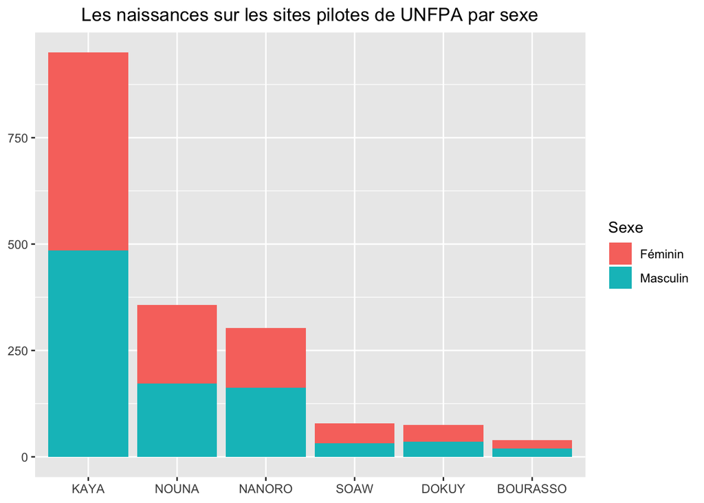

Les naissances sont plus nombreuses à Kaya, il faudrait donc s’attendre à ce que les intrants nécessaires à l’enrégistrement des naissances s’épuisent à Kaya bien avant les autres sites // There is more birth registration in Kaya, so it is to be expected that the inputs needed for birth registration will be exhausted in Kaya well before the other sites.

## 5.2 Sexe-ratio à la naissance pour les communes ayant plus de 100 naissances // Sex ratio at birth for relevant locations

| lieu_naissance | Féminin | Masculin | sexe_ratio | interpretation_sexe_ratio |
| --- | --- | --- | --- | --- |
| FADA | 317 | 354 | 1.1167192 | Plus de garçons que de filles |
| KAMBOINCE | 71 | 68 | 0.9577465 | Plus de filles que de garçons |
| KAYA | 465 | 485 | 1.0430108 | Plus de garçons que de filles |
| NANORO | 140 | 163 | 1.1642857 | Plus de garçons que de filles |
| NOUNA | 185 | 172 | 0.9297297 | Plus de filles que de garçons |
| OUAGADOUGOU | 1804 | 1846 | 1.0232816 | Plus de garçons que de filles |
| TENKODOGO | 198 | 234 | 1.1818182 | Plus de garçons que de filles |

```
## Coordinate Reference System:
##   User input: EPSG:4326
##   wkt:
## GEOGCS["WGS 84",
##     DATUM["WGS_1984",
##         SPHEROID["WGS 84",6378137,298.257223563,
##             AUTHORITY["EPSG","7030"]],
##         AUTHORITY["EPSG","6326"]],
##     PRIMEM["Greenwich",0,
##         AUTHORITY["EPSG","8901"]],
##     UNIT["degree",0.0174532925199433,
##         AUTHORITY["EPSG","9122"]],
##     AUTHORITY["EPSG","4326"]]
```

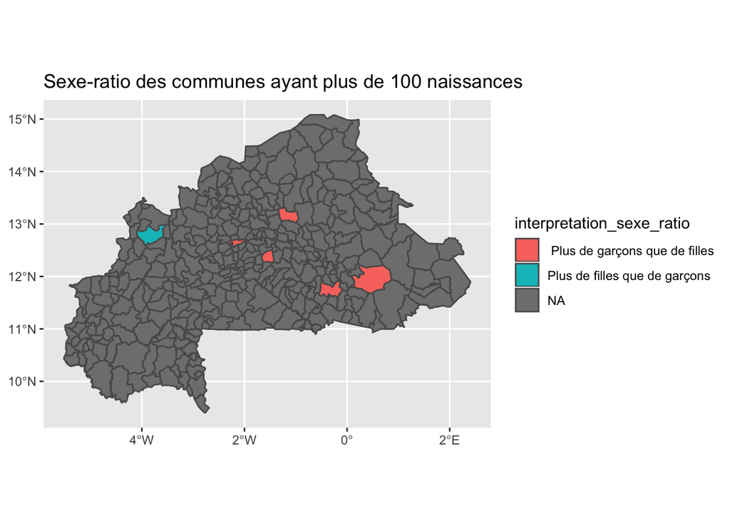

## 5.3 Nombre de declarations par lieu de naissance // Number of declarations by place of birth

| lieu_naissance | declaration | n |
| --- | --- | --- |
| BOBO DIOULASSO | FALSE | 2 |
| BOURASSO | FALSE | 30 |
| BOURASSO | TRUE | 9 |
| DOKUY | FALSE | 64 |
| DOKUY | TRUE | 11 |
| FADA | FALSE | 665 |
| FADA | TRUE | 6 |
| GUIRGHO | TRUE | 1 |
| KAMBOINCE | FALSE | 127 |
| KAMBOINCE | TRUE | 12 |

[output cut: 17 more lines]

| lieu_naissance | declaration | n | total_naissance |
| --- | --- | --- | --- |
| BOBO DIOULASSO | FALSE | 2 | 2 |
| BOURASSO | FALSE | 30 | 39 |
| BOURASSO | TRUE | 9 | 39 |
| DOKUY | FALSE | 64 | 75 |
| DOKUY | TRUE | 11 | 75 |
| FADA | FALSE | 665 | 671 |
| FADA | TRUE | 6 | 671 |
| GUIRGHO | TRUE | 1 | 1 |
| KAMBOINCE | FALSE | 127 | 139 |
| KAMBOINCE | TRUE | 12 | 139 |

[output cut: 17 more lines]

| lieu_naissance | declaration | n | total_naissance | taux_declaration |
| --- | --- | --- | --- | --- |
| BOURASSO | TRUE | 9 | 39 | 23.0769231 |
| DOKUY | TRUE | 11 | 75 | 14.6666667 |
| FADA | TRUE | 6 | 671 | 0.8941878 |
| GUIRGHO | TRUE | 1 | 1 | 100.0000000 |
| KAMBOINCE | TRUE | 12 | 139 | 8.6330935 |
| KAYA | TRUE | 364 | 950 | 38.3157895 |
| KODOUGOU | TRUE | 2 | 2 | 100.0000000 |
| LABARANI | TRUE | 11 | 11 | 100.0000000 |
| LEKUY | TRUE | 5 | 5 | 100.0000000 |
| NANORO | TRUE | 32 | 303 | 10.5610561 |

[output cut: 5 more lines]

Sur un total de 18 lieux de naissance (ou communes), 15 apparaissent comme lieux où s’est effectué au moins une déclaration. Les trois communes où aucune déclaration n’a eu lieu sont:

- BOBO DIOULASSO
- OUAHIGOUYA
- SOAW

On peut essayer de comprendre les raisons de cette absence de declaration à travers une analyse plus poussée tenant compte d’autres facteurs tels la position géographique de ces communes, l’existence et la proximité des centres d’état civil équipés du système iCivil.

Out of a total of 18 places of birth (or commune), 15 appear as places where at least one declaration was done. There were three municipalities whith no declaration:

- BOBO DIOULASSO
- OUAHIGOUYA
- SOAW

To understand the reason why no declaration was done in these three municipalities, it would be necessary to factor in the existence and closeness of civil registration centers equiped with iCivil in those regions.

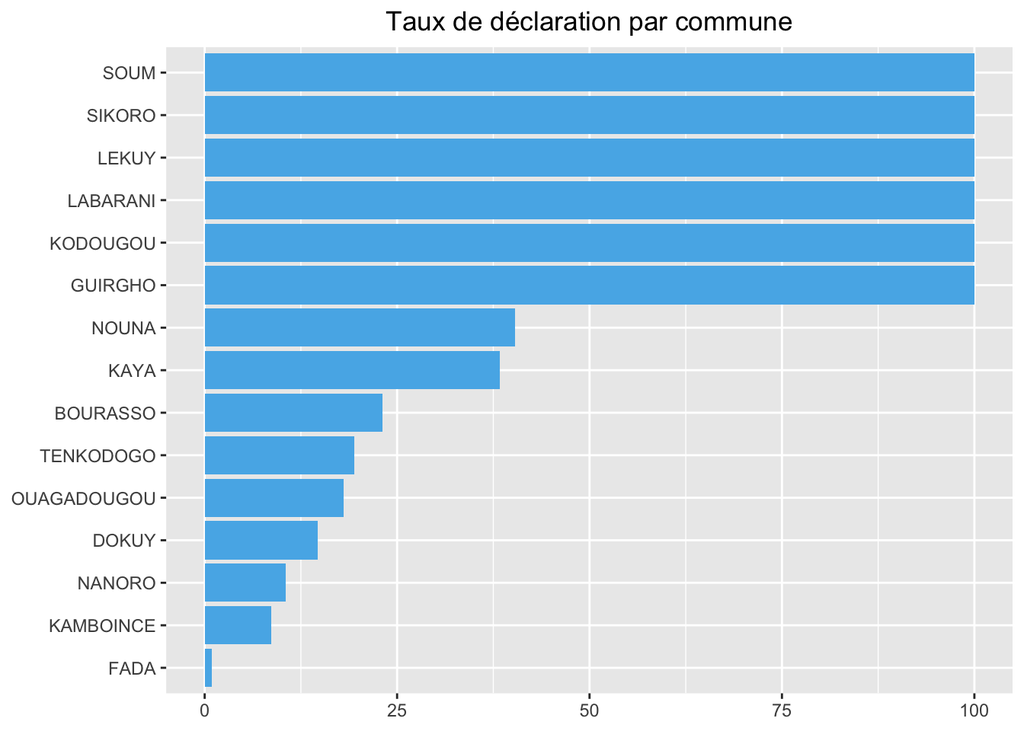

Malgré que iCivil soit installé à Ouagadougou depuis 4 ans, le taux de déclaration reste faible à 18.02 %. Par contre, dans les localités où l’UNFPA a déployé le système (localités plutôt rurales), le taux de déclaration parait interessant en l’espace de 2 mois. C’est le cas de Nouna avec un taux de 40.33 %, Kaya avec un taux de 38.31 %. A Nanoro, le taux de déclaration reste faible à 10.56 %. Certaines localités rurales affichent des taux de 100% même si elles ont chacunes enregistré moins de 12 naissances, ce qui n’est pas surprenant.

Although iCivil has been operating in Ouagadougou for 4 years, the declaration rate remains low at 18.02 %. However, in the UNFPA sites (rather rural areas), the declaration rate seems encouraging after just 2 months. In Nouna we have a rate of 40.33%, Kaya has a rate of 38.31%. In Nanoro, the declaration rate remains very low at 10.56%. Some others rural areas have rates of 100% though they only registered fewer than 12 births each.

## 5.4 Taux de declarations par sexe dans les communes // Rate of declaration by sexe, by municipality

| lieu_naissance | Sexe | declaration | n | total_naissance | taux_declaration_sex |
| --- | --- | --- | --- | --- | --- |
| BOURASSO | Féminin | TRUE | 5 | 39 | 12.8205128 |
| BOURASSO | Masculin | TRUE | 4 | 39 | 10.2564103 |
| DOKUY | Féminin | TRUE | 3 | 75 | 4.0000000 |
| DOKUY | Masculin | TRUE | 8 | 75 | 10.6666667 |
| FADA | Féminin | TRUE | 2 | 671 | 0.2980626 |
| FADA | Masculin | TRUE | 4 | 671 | 0.5961252 |
| GUIRGHO | Féminin | TRUE | 1 | 1 | 100.0000000 |
| KAMBOINCE | Féminin | TRUE | 6 | 139 | 4.3165468 |
| KAMBOINCE | Masculin | TRUE | 6 | 139 | 4.3165468 |
| KAYA | Féminin | TRUE | 175 | 950 | 18.4210526 |

[output cut: 18 more lines]

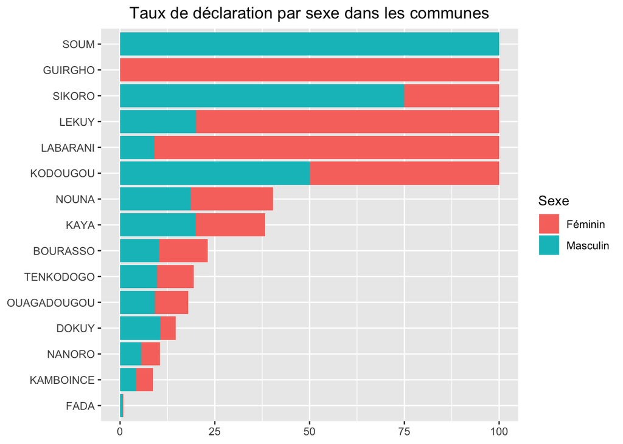

Pour l’analyse de ces graphes il serait plus intéressant de se focaliser sur les communes comme OUAGADOUGOU (3650), KAYA (950), FADA (671), TENKODOGO (432), NOUNA (357), NANORO (303), KAMBOINCE (139), qui ont enrégistré plus de 100 naissances. OUAGADOUGOU est particulièrement intéressant parcequ’elle dispose de données sur 4 années. Cependant, à mesure que la base recevra plus de données d’enregistrement, des analyses peuvent être faites sur l’ensemble des communes. Reprenons le graphe précédant en considérant ces communes.

[output not shown]

[output cut: 341 more lines]

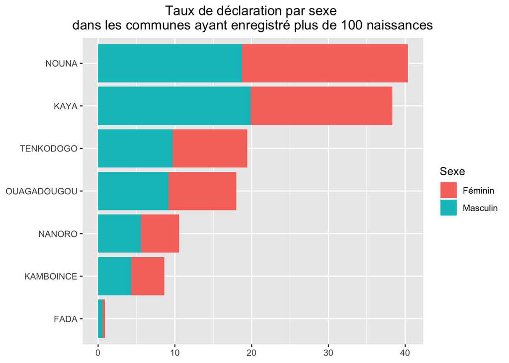

Nous constatons le faible taux de déclaration des naissances dans la commune de FADA qui pourtant se retrouve en 3e position en matière de nombre de naissances. Aussi, les communes de KAYA et NOUNA malgré qu’elles viennent de recevoir le système iCivil (il y a 2 mois avec les fonds innovation) affichent des taux de déclaration plutôt encourageants comparés à celui de OUAGADOUGOU qui dispose du système depuis 4 ans.

Une grande question pour le cas de Ouagadougou est de savoir si les gens ont toujours accès au système de déclaration traditionnel et, si oui, lequel ils préfèrent. Le taux de déclaration est probablement plus élevé si c’est le cas.

We note that the lowest rate of birth declaration is in FADA, yet the municipality has the 3rd highest number of births. Also, in KAYA and NOUNA despite the fact that they have just received the iCivil system (2 months ago) show rather encouraging rates of declaration compared to that of OUAGADOUGOU which has had the system for 4 years. Declaration by sex is more or less the same in most cities.

One major question for the case of Ouagadougou is whether or not people still have access to the traditional declaration system and if so, which one they prefer. the declaration rate is probably higher if that is the case.

# 6. Qui sont souvent les déclarants? // Who are the declarers of newborns?

| declarant | n |
| --- | --- |
| autre | 33 |
| grand frere | 1 |
| grand père | 1 |
| mere | 267 |
| oncle | 5 |
| pere | 1037 |

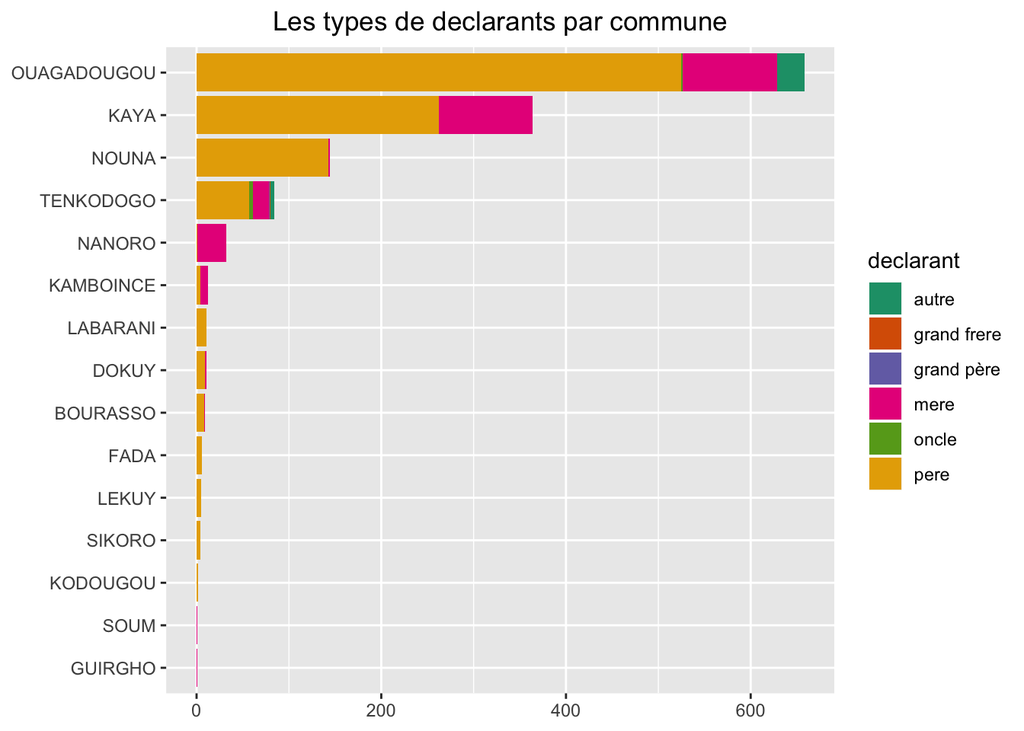

Les déclarations des naissances sont en générale faites par le père de l’enfant sauf à Nanoro où sur 32 nouveaux-nés, 31 ont été déclarés par leur mère. Cela a-t-il un lien avec le faible taux de déclaration à Nanoro constaté plus haut? Est-ce-que les pères des nouveaux-nés à Nanoro sont moins intéressés par la déclaration de leurs enfants comparés à ceux de Nouna et Kaya ?

Births are generally declared by the father of the newborn, except in Nanoro, where 31 out of 32 newborns were declared by their mother. Could this explain the low declaration rate in Nanoro as noted above? Are fathers of newborns in Nanoro less interested in declaring their children compared to those in Nouna and Kaya?

# 7. Détection des mères adolescentes / Teenage mothers

| date_activation | Sexe | date_naissance_enfant | lieu_naissance | lat | long | declarant | date_naissance_mere | age_mere |
| --- | --- | --- | --- | --- | --- | --- | --- | --- |
| 2020-03-17 | Féminin | 2020-03-03 | BOURASSO | NA | NA | Le père de l'enfant | 1979-01-01 | 41 |
| 2020-03-16 | Féminin | 2020-03-07 | NOUNA | NA | NA | Le père de l'enfant | 1987-08-13 | 33 |
| 2020-03-15 | Féminin | 2020-03-06 | KAYA | 13.15114 | -1.069817 | Le père de l'enfant | 1987-01-01 | 33 |
| 2020-03-14 | Masculin | 2020-03-14 | KAYA | NA | NA | Le père de l'enfant | 1983-05-15 | 37 |
| 2020-03-13 | Masculin | 2020-03-12 | NOUNA | 12.73358 | -3.839335 | Le père de l'enfant | 1994-12-31 | 26 |
| 2020-03-13 | Féminin | 2020-03-12 | LABARANI | 12.60068 | -3.631042 | Le père de l'enfant | 1905-06-21 | 115 |
| 2020-03-13 | Féminin | 2020-03-12 | KAYA | NA | NA | Le père de l'enfant | 1982-01-01 | 38 |
| 2020-03-12 | Féminin | 2020-03-12 | KAYA | 13.08365 | -1.076478 | Le père de l'enfant | 1989-02-26 | 31 |
| 2020-03-11 | Masculin | 2020-03-11 | KAYA | NA | NA | Le père de l'enfant | 1977-12-17 | 43 |
| 2020-03-11 | Masculin | 2020-03-10 | NOUNA | 12.63348 | -3.918213 | Le père de l'enfant | 1905-06-04 | 115 |

[output cut: 1334 more lines]

| date_activation | Sexe | date_naissance_enfant | lieu_naissance | lat | long | declarant | date_naissance_mere | age_mere |
| --- | --- | --- | --- | --- | --- | --- | --- | --- |
| 2020-03-10 | Féminin | 2020-02-26 | KAYA | 13.10471 | -1.165925 | La mère de l'enfant | 2004-03-02 | 16 |
| 2020-02-28 | Masculin | 2020-02-28 | KAYA | 13.08365 | -1.076437 | Le père de l'enfant | 2003-10-31 | 17 |
| 2020-02-24 | Féminin | 2020-02-06 | TENKODOGO | NA | NA | Le père de l'enfant | 2004-10-04 | 16 |
| 2020-02-19 | Masculin | 2020-02-19 | NANORO | 12.62418 | -2.131331 | La mère de l'enfant | 2005-12-31 | 15 |
| 2020-02-18 | Masculin | 2020-02-11 | KAYA | 13.20752 | -1.167944 | Le père de l'enfant | 2003-12-31 | 17 |
| 2020-02-17 | Masculin | 2020-02-15 | NANORO | 12.60001 | -2.29625 | La mère de l'enfant | 2004-04-13 | 16 |
| 2020-02-15 | Masculin | 2020-02-15 | KAYA | NA | NA | Le père de l'enfant | 2003-12-31 | 17 |
| 2020-02-13 | Féminin | 2020-02-13 | KAYA | NA | NA | Le père et la mère de l'enfant | 2003-01-30 | 17 |
| 2020-02-13 | Masculin | 2020-02-13 | KAYA | NA | NA | Le père de l'enfant | 2003-01-30 | 17 |
| 2020-02-12 | Féminin | 2020-01-31 | KAYA | NA | NA | Le père et la mère de l'enfant | 2003-01-01 | 17 |

[output cut: 14 more lines]

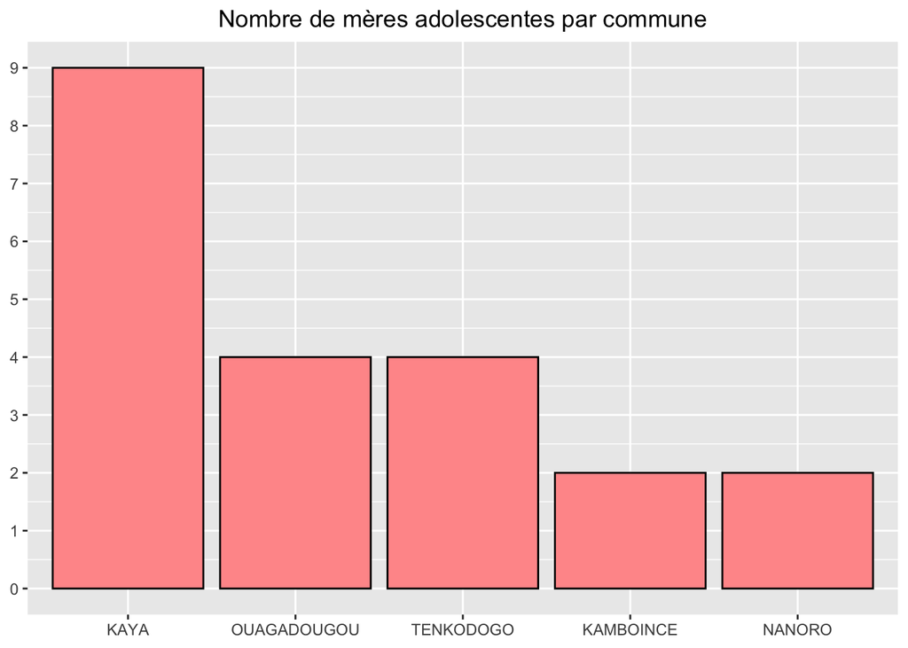

# 8. Le temps moyen mis par les populations pour déclarer les naissances // The average time taken by populations to declare births

La date de declaration n’est pas encore disponible mais j’ai crée une colonne avec des dates fictives pour l’analyse. Cette partie de l’analyse est donc purement fictive avec pour seul objectif de montrer comment on peut utiliser les dates pour certaines analyses.

The date of declaration is not yet available on the exported database but I created a column with fictitious dates for demonstration purpose. This part of the analysis is thus purely fictitious with the sole purpose of showing how the dates can be used for certain analyses.

| date_activation | Sexe | date_naissance_enfant | lieu_naissance | lat | long | declarant | date_naissance_mere | date_declaration |
| --- | --- | --- | --- | --- | --- | --- | --- | --- |
| 2020-03-18 | Masculin | 2020-03-17 | NOUNA | 12.75617 | -3.877577 | NA | NA | NA |
| 2020-03-18 | Féminin | 2020-03-17 | NOUNA | 12.75616 | -3.877474 | NA | NA | NA |
| 2020-03-18 | Féminin | 2020-03-17 | KAYA | 13.06218 | -1.087752 | NA | NA | NA |
| 2020-03-18 | Masculin | 2020-03-18 | KAYA | 13.06204 | -1.087689 | NA | NA | NA |
| 2020-03-17 | Féminin | 2020-03-17 | KAYA | NA | NA | NA | NA | NA |
| 2020-03-17 | Masculin | 2020-03-17 | KAYA | NA | NA | NA | NA | NA |
| 2020-03-17 | Féminin | 2020-03-17 | KAYA | NA | NA | NA | NA | NA |
| 2020-03-17 | Masculin | 2020-03-17 | KAYA | 13.18412 | -1.235491 | NA | NA | NA |
| 2020-03-17 | Masculin | 2020-03-17 | KAYA | 13.18412 | -1.235491 | NA | NA | NA |
| 2020-03-17 | Féminin | 2020-03-17 | KAYA | 13.18394 | -1.235398 | NA | NA | NA |

[output cut: 90 more lines]

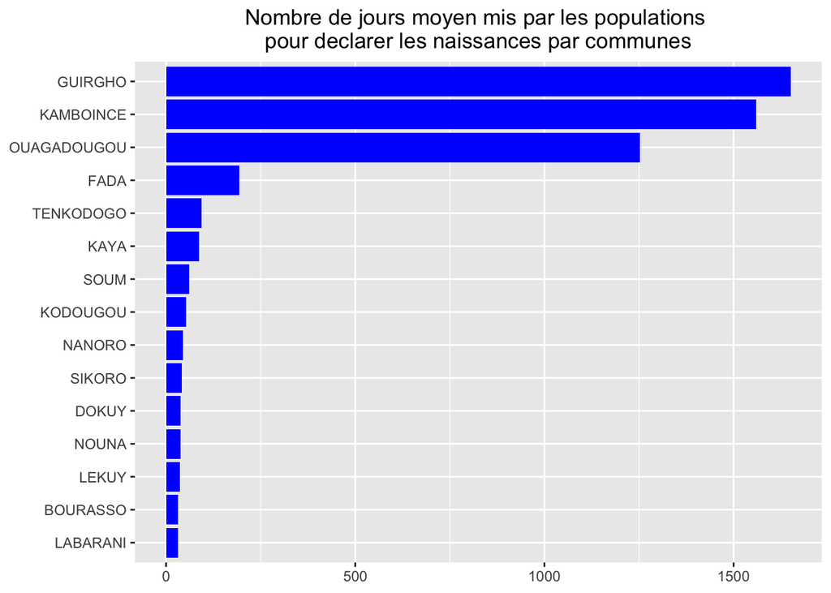

Il serait inutile de commenter ce graphe. Par contre, on sait que le délais légal pour déclarer un nouveau-né au Burkina Faso est de 2 mois. C’est ainsi dire que les déclarations faites dans les sites pilotes de l’UNFPA où la technologie iCivil vient d’être déployée (entre le 16 et le 24 Janvier) sont certainement dans les délais et peuvent être considérées comme les proportions réelles de déclaration dans ces milieux, pour la population considérée.

It would be pointless to comment on this graph. However, as we know that the legal time limit for declaring a newborn in Burkina Faso is 2 months, this means that the declarations made in the UNFPA pilot sites where the iCivil technology has just been deployed (16-24 Jan) are certainly within the timeframe and can be considered as the real proportions of declarations in these settings, for the considered population.